# Name:

Syeduzzaman Khan

# Project Title:

Selection of right Sport events and Athlete by analyzing Olympic Games data

# 1. Objectives:

The Olympic Games are considered the world's foremost sports competition with more than 200 nations participating. The Olympic Games are held every four years, with the Summer and Winter Games alternating by occurring every four years but two years apart. The given dataset contains almost all necessary information from Athens 1896 to Rio 2016.

The purpose of this project is to analysis the Olympics dataset and help Kellogg's to find appropriate sport event and athlete so that Kellogg's can be sponsor for the sport event and athlete on the next Olympics.

To achieve Kellogg's goals, we have to carefully analyze the dataset considering different perspectives. In the beginning of the project, we will get to familiar with dataset and look into different columns. Then, we will pick the relevant columns that will lead us to reach our goals. The obtained results will be visualized using plot and table.

# 2. Data Exploration:

Read dataset

```r
# read csv file
dataset <- read.csv ("athlete_events.csv", na.strings="",stringsAsFactors=FALSE)
```

Print top 10 rows, Number of rows, Number of columns, and Percantile

```r
cat("Display top 10 rows:") # print message
head (dataset,n=10) # print top 10 rows
cat("\n \n")
cat ("Number of Rows: ",nrow(dataset)) # calculate number of rows
cat ("\nNumber of Columns: ",ncol(dataset)) # calculate number of coloumns

# Percentiles of the numerical values

Height<-dataset$Height # sotre Height to Height variable
Height[Height=="NA"] <- "0" # missing values set to zero
Height<-as.numeric(Height)# convert to number
cat("\nPercentiles of Height [cm]: \n")
quantile(Height, prob = c(0.25, 0.50, 0.75)) # percentiles of Age

Age<-dataset$Age # sotre age to age variable
Age[Age=="NA"] <- "0" # missing values set to zero
Age<-as.numeric(Age)# convert to number
cat("\nPercentiles of Age [year]: \n")
quantile(Age, prob = c(0.25, 0.50, 0.75)) # percentiles of Age

Weight<-dataset$Weight # sotre weight to weight variable
Weight[Weight=="NA"] <- "0" # missing values set to zero
Weight<-as.numeric(Weight)# convert to number
cat("\nPercentiles of weights [kg]: \n")
quantile(Weight, prob = c(0.25, 0.50, 0.75)) # percentiles of weights
```

```
Display top 10 rows:
```

| ID | Name | Sex | Age | Height | Weight | Team | NOC | Games | Year | Season | City | Sport | Event | Medal |
| --- | --- | --- | --- | --- | --- | --- | --- | --- | --- | --- | --- | --- | --- | --- |
| 1 | A Dijiang | M | 24 | 180 | 80 | China | CHN | 1992 Summer | 1992 | Summer | Barcelona | Basketball | Basketball Men's Basketball | NA |
| 2 | A Lamusi | M | 23 | 170 | 60 | China | CHN | 2012 Summer | 2012 | Summer | London | Judo | Judo Men's Extra-Lightweight | NA |
| 3 | Gunnar Nielsen Aaby | M | 24 | NA | NA | Denmark | DEN | 1920 Summer | 1920 | Summer | Antwerpen | Football | Football Men's Football | NA |
| 4 | Edgar Lindenau Aabye | M | 34 | NA | NA | Denmark/Sweden | DEN | 1900 Summer | 1900 | Summer | Paris | Tug-Of-War | Tug-Of-War Men's Tug-Of-War | Gold |
| 5 | Christine Jacoba Aaftink | F | 21 | 185 | 82 | Netherlands | NED | 1988 Winter | 1988 | Winter | Calgary | Speed Skating | Speed Skating Women's 500 metres | NA |
| 5 | Christine Jacoba Aaftink | F | 21 | 185 | 82 | Netherlands | NED | 1988 Winter | 1988 | Winter | Calgary | Speed Skating | Speed Skating Women's 1,000 metres | NA |
| 5 | Christine Jacoba Aaftink | F | 25 | 185 | 82 | Netherlands | NED | 1992 Winter | 1992 | Winter | Albertville | Speed Skating | Speed Skating Women's 500 metres | NA |
| 5 | Christine Jacoba Aaftink | F | 25 | 185 | 82 | Netherlands | NED | 1992 Winter | 1992 | Winter | Albertville | Speed Skating | Speed Skating Women's 1,000 metres | NA |
| 5 | Christine Jacoba Aaftink | F | 27 | 185 | 82 | Netherlands | NED | 1994 Winter | 1994 | Winter | Lillehammer | Speed Skating | Speed Skating Women's 500 metres | NA |
| 5 | Christine Jacoba Aaftink | F | 27 | 185 | 82 | Netherlands | NED | 1994 Winter | 1994 | Winter | Lillehammer | Speed Skating | Speed Skating Women's 1,000 metres | NA |

```
Number of Rows:  271116
Number of Columns:  15
Percentiles of Height [cm]:
```

**25%**

157

**50%**

171

**75%**

180

```
Percentiles of Age [year]:
```

**25%**

21

**50%**

24

**75%**

28

```
Percentiles of weights [kg]:
```

**25%**

47

**50%**

64

**75%**

75

# 3. One column selection

```r
# select a column from dataset
Weight <- dataset$Weight # select column "Weight" and store it variable name Weight
Weight[Weight=="NA"] <- "0" # missing values are replaced by zero
Weight<-as.numeric(Weight) # factor to interger conversion
cat("10 largest values [Weight]:",head(sort(Weight,decreasing=TRUE),10)) # print 10 largest values
```

```
10 largest values [Weight]: 214 214 198 190 182 182 180 178 176.5 176.5
```

# 4. Sort

```r
# create new dataset: 5 columns
new_dataset<-dataset [dataset$Medal=="Gold",c("Age", "Height","Weight","Sport","Medal")] # dataset based on gold medal
cat("Dataset based on Gold medal: ")
head(new_dataset,5) # print top 5 rows of new dataset
# sorting columns : Age
Age <- new_dataset$Age # select column "Weight" and store it variable name Weight
Age[Age=="NA"] <- "0" # missing values are replaced by zero
Age<-as.numeric(Age) # factor to interger conversion
cat("Sorted column [Age-> top 5 values: year]:",head(sort(Age,decreasing=TRUE),5)) # print 5 largest values

# sorting columns : Height
Height <- new_dataset$Height # select column "Weight" and store it variable name Weight
Height[Height=="NA"] <- "0" # missing values are replaced by zero
Height<-as.numeric(Height) # factor to interger conversion
# comments on result
cat("\nSorted column [Height-> top 5 values in S.I unit: cm]:",head(sort(Height,decreasing=TRUE),5)) # print 5 largest values
cat("\n\nResults Explaination:")
cat("\nThe extracted new dataset will give a summary of original dataset. Here, all the required columns are gathered together for achieving our main research goals.  By analyzing it, we can get the idea regarding participants age, height,
weight, sports, and medals.")
```

```
Dataset based on Gold medal:
```

|  | Age | Height | Weight | Sport | Medal |
| --- | --- | --- | --- | --- | --- |
| 4 | 34 | NA | NA | Tug-Of-War | Gold |
| 43 | 28 | 175 | 64 | Gymnastics | Gold |
| 45 | 28 | 175 | 64 | Gymnastics | Gold |
| 49 | 28 | 175 | 64 | Gymnastics | Gold |
| 61 | 20 | 176 | 85 | Alpine Skiing | Gold |

```
Sorted column [Age-> top 5 values: year]: 64 64 63 63 63
Sorted column [Height-> top 5 values in S.I unit: cm]: 223 220 219 216 216

Results Explaination:
The extracted new dataset will give a summary of original dataset. Here, all the required columns are gathered together for achieving our main research goals.  By analyzing it, we can get the idea regarding participants age, height,
weight, sports, and medals.
```

# 5. Series:

```r
# Top medal numbers and Sports
medal_table<-as.data.frame(table(new_dataset$Sport, useNA="ifany")) # create dataframe for new dataset based on Sport
frequency<-as.numeric(tail(sort(medal_table$Freq),5)) # top frequency calculation
cat("List of most Olympic gold medals: ")
cat("    \n \tSports Name:",head(names(sort(table(new_dataset$Sport),decreasing=TRUE)), 5))# print top 5 sports that has won highest number of medal
cat("\n\tTotal Number:",sort(frequency,decreasing=TRUE))

# Avg. Age
cat("\nAverage Age [year]:",mean(Age))
# Avg. Height
cat("\nAverage Height [cm]:",mean(Height))
# Avg. Weight
cat("\nA\verage Weight [kg]:",mean(Weight))

# comments on result
cat("\n\nComments: The top five gold medal winning sports are Athletics, Swimming, Rowing, Gymnastics, and Fencing. Olympic gold medal winner can be categorized as their average age (25 years), height (140.20 cm), and weight (54 kg). By using the above data, Kellogg's can get idea to select the right sport and athletes.")
```

[output not shown]

# 6. Plot:

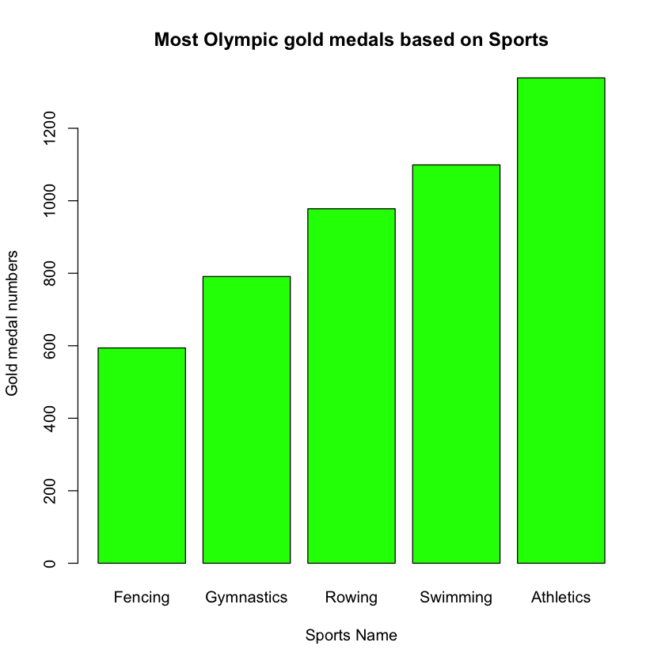

```r
# plot top sports that have won most gold medals
sport_name<-tail(names(sort(table(new_dataset$Sport))), 5) # sports name
# plot bar chart
barplot(frequency,names.arg=sport_name,xlab="Sports Name",ylab="Gold medal numbers",col="green",main="Most Olympic gold medals based on Sports")
```

# Advanced Level

```r
# sorting columns : Age
Age <- new_dataset$Age # select column "Age" and store it variable name Age
Age<-Age[Age!="NA"] # missing values are deleted
Age<-as.numeric(Age) # factor to interger conversion
cat("Sorted column [Age]:")
cat("\t15 Largest value [year]",head(sort(Age,decreasing=TRUE),15)) # print 5 largest values
cat("\n\t\t\t15 Smallest value [year]",head(sort(Age,decreasing=FALSE),15)) # print 5 largest values


# sorting columns : Height

Height <- new_dataset$Height # select column "Height" and store it variable name Height
Height<-Height[Height!="NA"] # missing values are deleted
Height<-as.numeric(Height) # factor to interger conversion
cat("\nSorted column [Height]:")
cat("\t15 Largest value [cm]",head(sort(Height,decreasing=TRUE),15)) # print 5 largest values
cat("\n\t\t\t15 Smallest value [cm]",head(sort(Height,decreasing=FALSE),15)) # print 5 largest values

#comments on result
cat("\n\nComments: In according to the data, the oldest gold medalist was 64 years old where as the yougest winner was only 13 years old. The age of oldest winner is fascinating that is quite impossible at the present days. Also, the height range varies from 136 to 223 cm.")
```

```
Sorted column [Age]:	15 Largest value [year] 64 64 63 63 63 63 60 60 60 60 59 59 58 58 58
			15 Smallest value [year] 13 13 13 13 13 13 13 14 14 14 14 14 14 14 14
Sorted column [Height]:	15 Largest value [cm] 223 220 219 216 216 216 216 216 214 213 213 213 213 213 213
			15 Smallest value [cm] 136 136 136 137 138 139 139 139 140 140 142 142 142 142 142

Comments: In according to the data, the oldest gold medalist was 64 years old where as the yougest winner was only 13 years old. The age of oldest winner is fascinating that is quite impossible at the present days. Also, the height range varies from 136 to 223 cm.
```

# 7. Summery:

The analysis of dataset represents a good insight of Olympic history. The dataset is reliable ( by size, rows: 271116, columns: 15). Therefore, the chance to get almost optimal solution for small projects is moderate.  
The contestants age range is 51 whereas the 75% percentile belongs to 28 years that is reasonable for athletes. The other data columns such as weight and height are also acceptable.

The list of top five Olympic gold medals by sports category are Athletics, Swimming, Rowing, Gymnastics, and Fencing and the total obtained medals are 1339, 1099, 978, 791, and 594 respectively. Those are popular and oldest events in Olympics. The above described result could help to choose a sport.

In order to select an athlete, we can set categories based on age, height and weight. In my opinion, it will not wise to select participants in according to their achieved medal. Because Olympics holds every 4 yours and athlete performance is mainly age dependents. If we select an athlete based on present performance, he will get older over the years that will slow down his reflex. So, Kellogg's can select athlete based on the winner athletes average age, weight and height.

# 8. Recommendations: